# Пятый этап Индивидуального проекта

Операционные системы - Бекауов А.Т

Российский университет дружбы народов, Москва, Россия

# Введение

## Цель работы

Целью данной работы продолжение редактирования сайта. Выполнить пятый этап индивидуального проекта.

# Выполнение этапа работы

## Добавления проекта ЛР

Первым делом зашёл в реопзиторий Ind_project в content/project и создал там папкт Labs_OS и Site_OS , зашёл в Labs_Os и запустил в редакторе gedit файл _index.md. В этом файле расписал проект выполнения лабораторных работ.

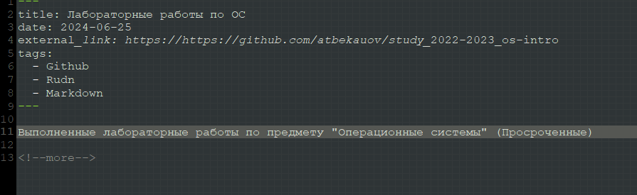

## Добавление проекта сайта

Затем перешёл в каталог Site_OS и запустил в редакторе gedit файл _index.md. В этом файле расписал проект выполнения индивидуального проекта.

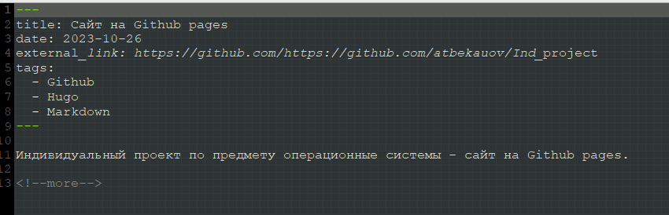

## Пост о прошедшей неделе

Затем перехожу в каталог Ind_project/content/posts и создаю две папки post 7 и post 8. Открываю папку post 7, открываю в gedit файл index.md и делаю пост о прошедшей неделе.

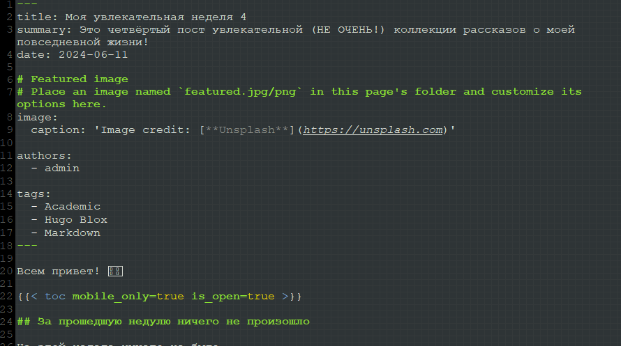

## Пост о языках программирования

Открываю папку post 8, открываю в gedit файл index.md и делаю пост о языках научного программирования

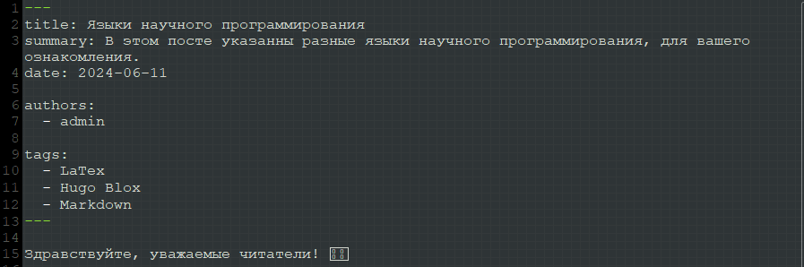

## Локальный сервер - проверка постов

Запускаю локальный сервер, с помощью hugo server и проверяю посты.

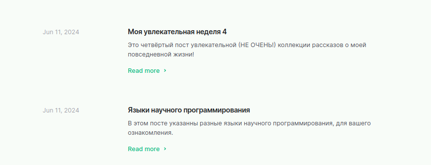

## Перенос изменений на сайт

Ввожу в репозитории Ind_project команду /~/bin/hugo. Далее перехожу в public и отправляю изменения на репозиторий atbekauov.github.io.

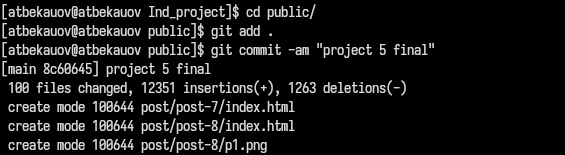

## Проверка сайта - пост про неделю

Захожу на сайт и проверяю пост про неделю.

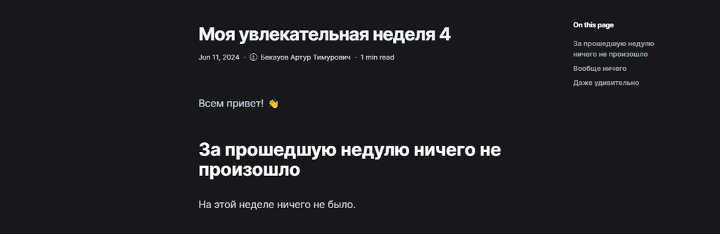

## Проверка сайта - пост про языки

Также проверяю пост про языки программирования.

[figure not shown]

## Проверка сайта - проекты

[figure not shown]

# Заключение

## Выводы

В ходе данной лаботраторной работы я продолжил редактирование сайта и выполнил пятый этап индивидуального проекта.